# Homework: Markov chains

**Author:** Brian Kwon

- `IMPORTANT`: We have decided to “shake it up” and introduce a `python` assignment, as a break from `R`.
- Therefore, this assignment MUST be done in `python`, NOT `R`

**Instructions**

- Read and work through all tutorial content and do all exercises below

**Submission:**

- You need to upload ONE document to Canvas when you are done
  - 1. An HTML (or PDF) version of the completed form of this notebook
- The final uploaded version should NOT have any code-errors present
- All outputs must be visible in the uploaded version, including code-cell outputs, images, graphs, etc

# Introduction

`Starter code`

## Import and parameters

```python
import numpy as np
import matplotlib.pyplot as plt

# PARAM SET
m=3
pu=0.2; pd=0.3; pl=0.25; pr=0.25
p=[pu,pd,pl,pr]
q=[0,0,0,0,1,0,0,0,0] #initial state probablities
```

## Overview

- Markov chains (MC) are important for understanding Markov Decision Processes, even though MC do not involve any decision-making.
- MCs are mathematical models describing particular types of stochastic processes.
- **Markov property:** The next state only depends on the current state, NOT past states
  - Denote the state at time $t$ by $s_t$
    $$p\left(s_{t+1} \mid s_t, s_{t-1}, s_{t-2}, \ldots, s_0\right)=p\left(s_{t+1} \mid s_t\right)$$
  - i.e. regardless of the past trajectory, the next state only depends on the current state
- **Markov chain:** A stochastic process where **ALL** states & times have the Markov property.

## Example: The broken robot

- Consider a robot which is stuck in a $m \times m$ grid world and can only make random moves.
- At EVERY step, the probability for up, down, left, and right is $\mathbf p=(0.2, 0.3, 0.25, 0.25)$
- You can think of $\mathbf p=(0.2, 0.3, 0.25, 0.25)$ as the “rules of the game”
- Assume that if the robot hits the wall, it bounces off and remains in the current state. However it’s probabilities for the next steps are still the same as before.
- Does the process have the Markov property? … Yes! Since, the probability of the next transition depends only on the current state.

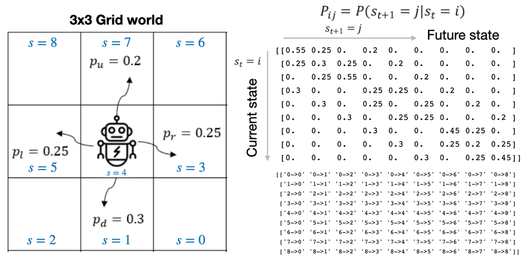

```python
0.25*0.25
```

```
0.0625
```

## Ergodicity

Time Averages vs. Ensemble Averages:

- In many situations, you might be interested in understanding the behavior of a system over a long time (time averages)
- or the behavior of multiple identical systems considered as a group (ensemble averages).
- Ergodicity implies that these two types of averages will be equivalent, given enough time.

Ergodicity refers to a property of a system or process in which time averages of a single system converge to ensemble averages of a collection of identical systems. It assumes that the system explores its entire state space over time, enabling meaningful equivalence between individual system behavior and group behavior.

## Transition probability matrix

```python
#SOURCE: 2020: Mastering reinforcement learning with python, enes bilgin (1st edition).
def get_P(m, p):
    p_up, p_down, p_left, p_right=p
    #print(p_up, p_down, p_left, p_right)
    m2 = m ** 2
    P = np.zeros((m2, m2))
    ix_map = {i + 1: (i // m, i % m) for i in range(m2)}
    for i in range(m2):
        for j in range(m2):
            r1, c1 = ix_map[i + 1]
            r2, c2 = ix_map[j + 1]
            rdiff = r1 - r2
            cdiff = c1 - c2
            if rdiff == 0:
                if cdiff == 1:
                    P[i, j] = p_left
                elif cdiff == -1:
                    P[i, j] = p_right
                elif cdiff == 0:
                    if r1 == 0:
                        P[i, j] = p_up
                    elif r1 == m - 1:
                        P[i, j] = p_down
                    if c1 == 0:
                        P[i, j] += p_left
                    elif c1 == m - 1:
                        P[i, j] += p_right
            elif rdiff == 1:
                if cdiff == 0:
                    P[i, j] = p_up
            elif rdiff == -1:
                if cdiff == 0:
                    P[i, j] = p_down
    return P

print("\nTRANSITION MATRIX: 3x3 \n",get_P(m, p))
```

```
TRANSITION MATRIX: 3x3
 [[0.45 0.25 0.   0.3  0.   0.   0.   0.   0.  ]
 [0.25 0.2  0.25 0.   0.3  0.   0.   0.   0.  ]
 [0.   0.25 0.45 0.   0.   0.3  0.   0.   0.  ]
 [0.2  0.   0.   0.25 0.25 0.   0.3  0.   0.  ]
 [0.   0.2  0.   0.25 0.   0.25 0.   0.3  0.  ]
 [0.   0.   0.2  0.   0.25 0.25 0.   0.   0.3 ]
 [0.   0.   0.   0.2  0.   0.   0.55 0.25 0.  ]
 [0.   0.   0.   0.   0.2  0.   0.25 0.3  0.25]
 [0.   0.   0.   0.   0.   0.2  0.   0.25 0.55]]
```

```python
# THIS SIMPLE CODE JUST SHOWS THE STATE TRANSITION MAPPINGS FOR THE TRANSITION MATRIX
tmp=[]
for i in range(0,m*m):
    tmp2=[]
    for j in range(0,m*m):
        tmp2.append(str(i)+"->"+str(j))
    tmp.append(tmp2)
tmp=np.array(tmp)
print(tmp)
```

```
[['0->0' '0->1' '0->2' '0->3' '0->4' '0->5' '0->6' '0->7' '0->8']
 ['1->0' '1->1' '1->2' '1->3' '1->4' '1->5' '1->6' '1->7' '1->8']
 ['2->0' '2->1' '2->2' '2->3' '2->4' '2->5' '2->6' '2->7' '2->8']
 ['3->0' '3->1' '3->2' '3->3' '3->4' '3->5' '3->6' '3->7' '3->8']
 ['4->0' '4->1' '4->2' '4->3' '4->4' '4->5' '4->6' '4->7' '4->8']
 ['5->0' '5->1' '5->2' '5->3' '5->4' '5->5' '5->6' '5->7' '5->8']
 ['6->0' '6->1' '6->2' '6->3' '6->4' '6->5' '6->6' '6->7' '6->8']
 ['7->0' '7->1' '7->2' '7->3' '7->4' '7->5' '7->6' '7->7' '7->8']
 ['8->0' '8->1' '8->2' '8->3' '8->4' '8->5' '8->6' '8->7' '8->8']]
```

## Code example: numpy

For positive integers n, the power is computed by repeated matrix squarings and matrix multiplications. If n == 0, the identity matrix of the same shape as M is returned. If n < 0, the inverse is computed and then raised to the abs(n).

```
linalg.matrix_power(a, n) --> Raise a square matrix to the (integer) power n.
```

```python
A=np.random.uniform(0,1,(3,3))
print("ORIGINAL:\n",A)
print("\nA**2.0 (component wise square): \n",A**2.0)
print("\nnp.matmul(A,A): \n",np.matmul(A,A))
print("\nnp.linalg.matrix_power(A,2): \n",np.linalg.matrix_power(A,2))
```

```
ORIGINAL:
 [[0.39728021 0.18775211 0.3050724 ]
 [0.71696446 0.6222347  0.82518232]
 [0.51930807 0.00771829 0.77566512]]

A**2.0 (component wise square):
 [[1.57831562e-01 3.52508559e-02 9.30691677e-02]
 [5.14038033e-01 3.87176020e-01 6.80925858e-01]
 [2.69680875e-01 5.95720452e-05 6.01656374e-01]]

np.matmul(A,A):
 [[0.45086971 0.19377072 0.51276297]
 [1.15947979 0.52815661 1.37224828]
 [0.61465372 0.10829059 0.76645193]]

np.linalg.matrix_power(A,2):
 [[0.45086971 0.19377072 0.51276297]
 [1.15947979 0.52815661 1.37224828]
 [0.61465372 0.10829059 0.76645193]]
```

# Assignment

Follow the instructions in the comments

## Assignment-0: Simulate the robot

- Lets simulate the broken robot
- To estimate the steady state occupation probabilities, we can simply simulate the system for a long enough time so that the probabilities eventually converge.
- The function inputs are
  - The grid size $m=3$ $\rightarrow$ $m \times m=3 \times 3$
  - The probability $p$ for up,down,left,right moves
  - The initial probabilities distribution vector $q$

```python
# INSERT CODE TO SIMULATE THE BROKEN ROBOT GIVEN THE INPUTS
    # YOU SHOULD ACTUALLY SIMULATE THE PROCESS BY HAVING THE ROBOT "WALK" AROUND
    # THE SPACE INSIDE A TIME LOOP BASED ON THE p=[pu,pd,pl,pr=0.25]
    # ALSO CODED SO IT "BOUNCES" OFF WHEN IT STEPS INTO A WALL AND RETURNS TO THE ORIGINAL CELL
# THE FUNCTION SHOULD OUTPUT TWO THINGS
    # 1) THE TIME-AVERAGE OCCUPATION PROBABILITY FOR EACH STATE (STORED AS AN m by m MATRIX)
    # 2) THE OCCUPIED STATE AT THE nth TIME-STEP (STORED AS AN m by m MATRIX OF ZEROS AND ONES)

def simulate_robot(n=100000,m=3,q=[0,0,0,0,1,0,0,0,0], p = [0.2, 0.3, 0.25, 0.25]):
    # n=NUMBER OF TIME-STEPS
    # q=INITIALIZATION PROBABILITY: IC MUST BE A VECTOR OF LENGTH (m**2,1) WHICH SUMS TO 1
    # p=[pu=0.2; pd=0.3; pl=0.25; pr=0.25];

    # INSERT YOUR CODE
    Nn = np.array(q).reshape((m,m))
    Ns = np.array(q).reshape((m,m))

    for _ in range(n):
        move = np.random.choice(["Up","Down","Left","Right"], p=p)
        idx = np.where(Nn==1)
        if move == "Up":
            if idx[0]-1 < 0:
                Nn = Nn
            else:
                Nn[idx] = 0
                Nn[idx[0]-1,idx[1]] = 1

        elif move =="Down":
            if idx[0]+1 == 3:
                Nn = Nn
            else:
                Nn[idx] = 0
                Nn[idx[0]+1,idx[1]] = 1

        elif move == "Left":
            if idx[1]-1 < 0:
                Nn = Nn
            else:
                Nn[idx] = 0
                Nn[idx[0],idx[1]-1] = 1

        elif move == "Right":
            if idx[1]+1 == 3:
                Nn = Nn
            else:
                Nn[idx] = 0
                Nn[idx[0],idx[1]+1] = 1
        Ns = Ns + Nn


    return [Ns/n,Nn]
```